# Assignment-5

### Import necessary libraries

```python
import pandas as pd
import numpy as np
import matplotlib.pyplot as plt
from IPython.display import HTML
import base64
```

```python
def splitTrainTest(data,percent):
    total=len(data)
    trainTotal=int(total*percent*0.01)
    testTotal=total-trainTotal
    return (data[0:trainTotal],data[trainTotal:total])
```

### Layer Class

This class's object represent the layers in neural network. It stores the number of neurons in each layers, activations, activation function associated with each layer and their weight vector (initialize on gaussian distribute with mean =0 and std deviation=1).

```python
class Layer:
    def __init__(self,nNodesCurrent, nNodesNext, activationF):
        self.nodesNo=nNodesCurrent
        self.activations = np.zeros([nNodesCurrent,1])
        self.activationF=activationF
        if nNodesNext==0:
            self.weights=None
        else:
            self.weights=np.random.normal(0, 1, size=(nNodesCurrent,nNodesNext))
```

### Neural Network Class

Class of neural network to perform multiclass classification using the cross entropy as cost function and softmax as probabilty distribution activation function.

This class perform following tasks:

- Initialized the number of layers in neural network and create **Layer Class** object.
- Train the neural network on batches of inputs there by performing the forward and backward propogation using below helper methods.

#### Methods:

1. **Forward Propogation** : Perform the forward propogation, calculate and stores activations at each of the layer. $$ z_1= w_1^TX $$ $$ a_1= f _1(z_1) $$ $$ z_2= w_2^Ta_1 $$ $$ \hat{y}= a_2= f_2(z_2) $$
2. **Calculate Error** : Here we calculate the cross entropy error of our neural network on the updated activations. This updation in activation take place after the updation of weights in gradient decent algorithm in backpropogation.
   For multiclass classification we use the below cross entropy cost function: $$ J = -\sum\limits_{i} y \log \; \hat{y} $$
3. **Backward Propogation** : Here, we differentiate the cost function to minimize it, and find the optimal values of parameters ie weights at each of the layer. $$\frac{\partial J}{\partial w_2 } = \frac{\partial J}{\partial \hat{y} } * \frac{\partial \hat{y}}{\partial z_2 } * \frac{\partial z_2}{\partial w_2 } $$
   also for cross entropy as a cost function and softmax as $f_2(z_2)$ , $$ \delta_3 = \frac{\partial J}{\partial \hat{y} } * \frac{\partial \hat{y}}{\partial z_2 } = (y_p - y_a) $$
   $$ \therefore \frac{\partial J}{\partial w_2 }= (\hat{y} - y) * a_1$$
   Similarly to calculate parital derivative w.r.t weights of inner layers, we can use the chain rule $$ \frac{\partial J}{\partial w_1 } = x^T * \delta_3 * w_2 * f^1 (z_1) $$
4. **Get Accuracy**: This function will return the accuracy of our neural network on multiclass classification.

**Some important activations functions and their derivatives used in our network** **Softmax**
$$\sigma (z)_j = \frac{e^{z_j}}{\sum^K_{k=1} e^{z_j}}$$ **Sigmoid**
$$sigmoid(x) = \frac{1}{1+\epsilon ^ {-x}}$$ $$\frac{\partial sigmoid(x)}{\partial x} = sigmoid(x) * ( 1- sigmoid(x))$$

**tanh**
$$tanh(x) = \tanh{(x)}$$
$$\frac{\partial tanh(x)}{\partial x} = 1 - \tanh^2{(x)}$$

```python
class NeuralNet:
    def __init__(self, totalLayers, noNodesList, activationFunctions):
        self.totalLayers=totalLayers
        self.noNodesList=noNodesList
        self.layers = []
        for i in range(totalLayers):
            currentLayerNodes=noNodesList[i]
            if i!=totalLayers-1:
                nextLayerNodes=noNodesList[i+1]
                ith_Layer=Layer(currentLayerNodes,nextLayerNodes,activationFunctions[i])
            else:
                ith_Layer=Layer(currentLayerNodes,0,activationFunctions[i])
            self.layers.append(ith_Layer)#append output layer as none

    def trainNetwork(self, data,outputLabels, batchSize, epochs, learningRate,notforGraph=True):
        self.learningRate=learningRate
        self.batchSize=batchSize;

        #normalize data
#         data=((data-data.min(axis=0))/(data.max(axis=0)-data.min(axis=0)))
#         data=data/255

        for x in range(epochs):
            i=0
            while i<len(data):
                self.error=0
                self.forwardPropo(data[i:i+batchSize])#input
                self.calculateError(outputLabels[i:i+batchSize])#output
                self.backwardPropo(outputLabels[i:i+batchSize])
                i+=batchSize
            self.error /= batchSize
            if notforGraph:
                print("Epoch ",x,"->Error: ", self.error)
        if notforGraph==False:
            print(self.error)
            return self.error


    def forwardPropo(self, inputs):
        self.layers[0].activations =inputs
        for i in range(self.totalLayers-1):
            temp=np.matmul(self.layers[i].activations,self.layers[i].weights)
            if self.layers[i+1].activationF == "sigmoid":
                self.layers[i+1].activations = self.sigmoid(temp)
            elif self.layers[i+1].activationF == "softmax":
                self.layers[i+1].activations = self.softmax(temp)
            elif self.layers[i+1].activationF == "relu":
                self.layers[i+1].activations = self.relu(temp)
            elif self.layers[i+1].activationF == "tanh":
                self.layers[i+1].activations = self.tanh(temp)
            else:
                self.layers[i+1].activations = temp

    def calculateError(self,labels):
        if len(labels[0]) != self.layers[self.totalLayers-1].nodesNo:
            print ("Error: Label is not of the same shape as output layer.")
            print("Label: ", len(labels), " : ", len(labels[0]))
            print("Out: ", len(self.layers[self.totalLayers-1].activations), " : ", len(self.layers[self.totalLayers-1].activations[0]))
            return
        self.error += np.negative(np.sum(np.multiply(labels, np.log(self.layers[self.totalLayers-1].activations))))

    def backwardPropo(self, labels):
        targets = labels
        i = self.totalLayers-1
        y = self.layers[i].activations

        delta=(y-targets)
        deltaw = np.dot(self.layers[i-1].activations.T, delta)/self.batchSize
        new_weights = self.layers[i-1].weights - self.learningRate * deltaw
        for i in range(i-1, 0, -1):
            if self.layers[i].activationF=="sigmoid":
                prime= self.sigmoid_derivative(np.matmul(self.layers[i-1].activations,self.layers[i-1].weights))
            elif self.layers[i].activationF=="relu":
                prime= self.relu_derivative(np.matmul(self.layers[i-1].activations,self.layers[i-1].weights))
            elif self.layers[i].activationF=="tanh":
                prime= self.tanh_derivative(np.matmul(self.layers[i-1].activations,self.layers[i-1].weights))

            delta=np.multiply(prime,delta.dot(self.layers[i].weights.T))
            deltaw = np.dot(self.layers[i-1].activations.T, delta)/self.batchSize

            self.layers[i].weights = new_weights
            new_weights = self.layers[i-1].weights - self.learningRate * deltaw
        self.layers[0].weights = new_weights

    def predict(self,inputs):
#         inputs=inputs/255
        self.batchSize = len(inputs)
        self.forwardPropo(inputs)
        a = self.layers[self.totalLayers-1].activations
        predictions=[]
        actuals=[]
        for i in range(len(a)):
            al=a[i].tolist()
            predictions.append(al.index(max(al)))
#             actuals.append(labels[i])

        a = np.array(predictions)
#         b = np.array(actuals)
#         df = pd.DataFrame({"predictions" : a, "actuals" : b})
        df = pd.DataFrame({"predictions" : a})
#         df.to_csv("predictions.csv", index=False)
        return self.create_download_link(df)


    def getAccuracy(self, inputs, labels, forGraph=False):
#         inputs=inputs/255
        self.batchSize = len(inputs)
        self.forwardPropo(inputs)
        a = self.layers[self.totalLayers-1].activations
#         print(len(a))
        total=0
        correct=0
        for i in range(len(a)):
            total += 1
            al = a[i].tolist()
            if labels[i][al.index(max(al))] == 1:
                correct += 1
#         print(correct)
        accuracy=correct/total
        print("Accuracy: ", accuracy)
        if forGraph:
            return 1-accuracy

    def sigmoid(self, x):
        return np.divide(1, np.add(1, np.exp(np.negative(x))))

    def sigmoid_derivative(self,x):
        return (self.sigmoid(x)*(1-self.sigmoid(x)))

    def relu(self, x):
        return (x/700) * (x > 0)

    def relu_derivative(self,X):
        return 1. * (X > 0)

    def softmax(self, x):
        x=np.nan_to_num(x)
        exp = np.exp(x)
        if isinstance(x[0], np.ndarray):
            return exp/np.sum(exp, axis=1, keepdims=True)
        else:
            return exp/np.sum(exp, keepdims=True)

    def tanh(self, x):
        return np.tanh(x)

    def tanh_derivative(self,x):
        return 1.0 - np.tanh(x) ** 2

    def create_download_link(self,df, title = "Download CSV file", filename = "predictions.csv"):
        csv = df.to_csv()
        b64 = base64.b64encode(csv.encode())
        payload = b64.decode()
        html = '<a download="{filename}" href="data:text/csv;base64,{payload}" target="_blank">{title}</a>'
        html = html.format(payload=payload,title=title,filename=filename)
        return HTML(html)
```

```python
def getOneHotLabels(data,k):
    one_hot_labels = np.zeros((len(data), k))
    for i in range(len(data)):
        one_hot_labels[i,int(data[i,0])] = 1
    return one_hot_labels
```

```python
data=pd.read_csv("apparel-trainval.csv").values
# testdata=pd.read_csv("../input/fashionmnist/fashion-mnist_test.csv").values
testdata=pd.read_csv("apparel-test.csv").values
```

### Question-1 Neural network with different activation functions in hidden layers

**Sigmoid**

```python
train,test=splitTrainTest(data,80)
oneHotLabelsTrain=getOneHotLabels(train,10)
oneHotLabelsTest=getOneHotLabels(test,10)
trainInputs=train[:,1:]
testInputs=test[:,1:]
print("Neural network with sigmoid activation function in hidden layers")

numberofLayers=4
noofneurons=[784,16,16,10]
activationFunctions=[None,"sigmoid","sigmoid","softmax"]
batchSize=64
epochs=50
learningRat=0.6
trainInputs=trainInputs/255
testInputs=testInputs/255

#NeuralNet(noLayers, noNeurons in each layer, activationFunctions)
nn=NeuralNet(numberofLayers,noofneurons,activationFunctions)
nn.trainNetwork(trainInputs,oneHotLabelsTrain,batchSize,epochs,learningRat)
nn.getAccuracy( testInputs, oneHotLabelsTest)
```

```
Neural network with sigmoid activation function in hidden layers
Epoch  0 ->Error:  0.6165582923007848
Epoch  1 ->Error:  0.5206524381395075
Epoch  2 ->Error:  0.4799528735681894
Epoch  3 ->Error:  0.4356883632718586
Epoch  4 ->Error:  0.40810126359723264
Epoch  5 ->Error:  0.4018907150805
Epoch  6 ->Error:  0.3883404118335379
Epoch  7 ->Error:  0.3738365064323199
Epoch  8 ->Error:  0.3596605666932567
Epoch  9 ->Error:  0.3488892136189778
Epoch  10 ->Error:  0.34009055786398934
Epoch  11 ->Error:  0.3354039246256605
Epoch  12 ->Error:  0.33085694805240584
Epoch  13 ->Error:  0.3278803283351729
Epoch  14 ->Error:  0.32580500570159976
Epoch  15 ->Error:  0.3229925834745141
Epoch  16 ->Error:  0.31985198962166644
Epoch  17 ->Error:  0.31623595593999854
Epoch  18 ->Error:  0.31234874476839875
Epoch  19 ->Error:  0.30873640912519046
Epoch  20 ->Error:  0.3053907331386861
Epoch  21 ->Error:  0.3021227206438414
Epoch  22 ->Error:  0.29881303665749415
Epoch  23 ->Error:  0.2955316201517244
Epoch  24 ->Error:  0.2931786003824869
Epoch  25 ->Error:  0.28382406542571975
Epoch  26 ->Error:  0.28056373365277326
Epoch  27 ->Error:  0.27859164908937784
Epoch  28 ->Error:  0.2771736365530648
Epoch  29 ->Error:  0.27683085998111084
Epoch  30 ->Error:  0.27513065912540535
Epoch  31 ->Error:  0.27316636012441364
Epoch  32 ->Error:  0.27124551143833453
Epoch  33 ->Error:  0.27008927450434955
Epoch  34 ->Error:  0.2696247306684887
Epoch  35 ->Error:  0.2692191321566222
Epoch  36 ->Error:  0.26856627234488695
Epoch  37 ->Error:  0.26709308013899113
Epoch  38 ->Error:  0.2646030334117917
Epoch  39 ->Error:  0.2618277376827399
Epoch  40 ->Error:  0.2589128525753285
Epoch  41 ->Error:  0.25583496800871786
Epoch  42 ->Error:  0.25370577737861544
Epoch  43 ->Error:  0.2521111827556464
Epoch  44 ->Error:  0.25045986092572897
Epoch  45 ->Error:  0.24900126893077407
Epoch  46 ->Error:  0.24791451318956992
Epoch  47 ->Error:  0.24686289729293828
Epoch  48 ->Error:  0.24584388052521092
Epoch  49 ->Error:  0.24486521941274736
Accuracy:  0.8484166666666667
```

**ReLU**

```python
train,test=splitTrainTest(data,80)
oneHotLabelsTrain=getOneHotLabels(train,10)
oneHotLabelsTest=getOneHotLabels(test,10)
trainInputs=train[:,1:]
testInputs=test[:,1:]

# testUnseen=testdata#this is input as well

print("Neural network with reLU activation function in hidden layers")

numberofLayers=4
noofneurons=[784,16,16,10]
activationFunctions=[None,"relu","relu","softmax"]
batchSize=64
epochs=50
learningRat=0.6
trainInputs=trainInputs/255
testInputs=testInputs/255
# testUnseen=testUnseen/255

#NeuralNet(noLayers, noNeurons in each layer, activationFunctions)
nn=NeuralNet(numberofLayers,noofneurons,activationFunctions)

nn.trainNetwork(trainInputs,oneHotLabelsTrain,batchSize,epochs,learningRat)

nn.getAccuracy( testInputs, oneHotLabelsTest)
# nn.predict(testUnseen)
```

```
Neural network with reLU activation function in hidden layers
Epoch  0 ->Error:  0.5799010762338455
Epoch  1 ->Error:  0.4535244833882113
Epoch  2 ->Error:  0.3935248946359241
Epoch  3 ->Error:  0.36950690448969636
Epoch  4 ->Error:  0.34256022038881884
Epoch  5 ->Error:  0.310959811586045
Epoch  6 ->Error:  0.2831442929030752
Epoch  7 ->Error:  0.27109226943822246
Epoch  8 ->Error:  0.2532896336748023
Epoch  9 ->Error:  0.24584798021183032
Epoch  10 ->Error:  0.23803299175446108
Epoch  11 ->Error:  0.230422170463919
Epoch  12 ->Error:  0.22295011247436164
Epoch  13 ->Error:  0.22285985228628602
Epoch  14 ->Error:  0.21493595335660937
Epoch  15 ->Error:  0.2105207779798516
Epoch  16 ->Error:  0.2018355026006139
Epoch  17 ->Error:  0.2036946816780481
Epoch  18 ->Error:  0.19736965433462803
Epoch  19 ->Error:  0.19795596332728121
Epoch  20 ->Error:  0.19562867068572815
Epoch  21 ->Error:  0.1910218630208594
Epoch  22 ->Error:  0.1919893754442967
Epoch  23 ->Error:  0.19461466448674647
Epoch  24 ->Error:  0.1878984020523008
Epoch  25 ->Error:  0.1889850313552554
Epoch  26 ->Error:  0.18576519619912346
Epoch  27 ->Error:  0.18492161654551692
Epoch  28 ->Error:  0.18546822596047835
Epoch  29 ->Error:  0.18494122087323372
Epoch  30 ->Error:  0.18560216138217167
Epoch  31 ->Error:  0.18160948637323246
Epoch  32 ->Error:  0.18301848878284233
Epoch  33 ->Error:  0.18507855908273185
Epoch  34 ->Error:  0.18301888225638466
Epoch  35 ->Error:  0.18219486761070874
Epoch  36 ->Error:  0.18462325564486617
Epoch  37 ->Error:  0.18229694934701546
Epoch  38 ->Error:  0.18237006105173034
Epoch  39 ->Error:  0.18354210061997142
Epoch  40 ->Error:  0.18325909324492093
Epoch  41 ->Error:  0.18013823553738692
Epoch  42 ->Error:  0.17679307140600797
Epoch  43 ->Error:  0.1794585576233631
Epoch  44 ->Error:  0.17970799077910904
Epoch  45 ->Error:  0.17689008082233887
Epoch  46 ->Error:  0.1748992293356047
Epoch  47 ->Error:  0.1784140289228041
Epoch  48 ->Error:  0.17653124119222668
Epoch  49 ->Error:  0.17056519943186813
Accuracy:  0.8554166666666667
```

**Tanh**

```python
train,test=splitTrainTest(data,80)
oneHotLabelsTrain=getOneHotLabels(train,10)
oneHotLabelsTest=getOneHotLabels(test,10)
trainInputs=train[:,1:]
testInputs=test[:,1:]
print("Neural network with tanh activation function in hidden layers")

numberofLayers=4
noofneurons=[784,16,16,10]
activationFunctions=[None,"tanh","tanh","softmax"]
batchSize=64
epochs=50
learningRat=0.3
trainInputs=trainInputs/255
testInputs=testInputs/255


#NeuralNet(noLayers, noNeurons in each layer, activationFunctions)
nn=NeuralNet(numberofLayers,noofneurons,activationFunctions)
nn.trainNetwork(trainInputs,oneHotLabelsTrain,batchSize,epochs,learningRat)
nn.getAccuracy( testInputs, oneHotLabelsTest)
```

```
Neural network with tanh activation function in hidden layers
Epoch  0 ->Error:  0.8990656927627994
Epoch  1 ->Error:  0.7008093233971553
Epoch  2 ->Error:  0.6032985392777387
Epoch  3 ->Error:  0.5979628484447557
Epoch  4 ->Error:  0.5669805419797008
Epoch  5 ->Error:  0.5689650864574178
Epoch  6 ->Error:  0.5601066404057373
Epoch  7 ->Error:  0.5032674678485793
Epoch  8 ->Error:  0.5137451507030399
Epoch  9 ->Error:  0.5137763813017369
Epoch  10 ->Error:  0.5370644866315619
Epoch  11 ->Error:  0.4953503691358875
Epoch  12 ->Error:  0.5314025512268556
Epoch  13 ->Error:  0.4922301586914205
Epoch  14 ->Error:  0.45431425520711893
Epoch  15 ->Error:  0.4456304536229523
Epoch  16 ->Error:  0.4549515652620307
Epoch  17 ->Error:  0.4558763650449982
Epoch  18 ->Error:  0.4207828700643542
Epoch  19 ->Error:  0.47231812984584254
Epoch  20 ->Error:  0.4173805530110375
Epoch  21 ->Error:  0.3997724706408954
Epoch  22 ->Error:  0.4654533725555975
Epoch  23 ->Error:  0.3868550377328178
Epoch  24 ->Error:  0.37716669024570265
Epoch  25 ->Error:  0.3910690687052978
Epoch  26 ->Error:  0.389026432487528
Epoch  27 ->Error:  0.36706734260413576
Epoch  28 ->Error:  0.3512060624577819
Epoch  29 ->Error:  0.3744370954873708
Epoch  30 ->Error:  0.39254152806586423
Epoch  31 ->Error:  0.3680565893300538
Epoch  32 ->Error:  0.3726286750503546
Epoch  33 ->Error:  0.4273174115413822
Epoch  34 ->Error:  0.3595729164985228
Epoch  35 ->Error:  0.3663827449186201
Epoch  36 ->Error:  0.3818646741431472
Epoch  37 ->Error:  0.3768876731889475
Epoch  38 ->Error:  0.3811576796043801
Epoch  39 ->Error:  0.3717712560672637
Epoch  40 ->Error:  0.3370722819218101
Epoch  41 ->Error:  0.3579509412545281
Epoch  42 ->Error:  0.4772877551298501
Epoch  43 ->Error:  0.3692727791735571
Epoch  44 ->Error:  0.3502152870394262
Epoch  45 ->Error:  0.3548557406057765
Epoch  46 ->Error:  0.35979719102843866
Epoch  47 ->Error:  0.35069696497114766
Epoch  48 ->Error:  0.3617029766565182
Epoch  49 ->Error:  0.33601995155647735
Accuracy:  0.8194166666666667
```

### Question-1 Graph of Error vs Number of epochs for different activation functions used in hidden layers

```python
def errorPlot():
    data=pd.read_csv("apparel-trainval.csv").values
    sigmoidError=[]
    reluError=[]
    tanhError=[]
    xlist=[i for i in range(1,55)]
    train,test=splitTrainTest(data,80)
    oneHotLabelsTrain=getOneHotLabels(train,10)
    oneHotLabelsTest=getOneHotLabels(test,10)
    trainInputs=train[:,1:]
    testInputs=test[:,1:]

    trainInputs=trainInputs/255
    testInputs=testInputs/255


    numberofLayers=4
    noofneurons=[784,16,16,10]
    activationFunctionsRelu=[None,"relu","relu","softmax"]
    activationFunctionsSigmoid=[None,"sigmoid","sigmoid","softmax"]
    activationFunctionsTanh=[None,"tanh","tanh","softmax"]
    batchSize=64

    for i in xlist:
        print(i)
        nnSigmoid=NeuralNet(numberofLayers,noofneurons,activationFunctionsSigmoid)
        nnRelu=NeuralNet(numberofLayers,noofneurons,activationFunctionsRelu)
        nnTanh=NeuralNet(numberofLayers,noofneurons,activationFunctionsTanh)

        nnSigmoid.trainNetwork(trainInputs,oneHotLabelsTrain,batchSize,i,0.1,False)
        nnRelu.trainNetwork(trainInputs,oneHotLabelsTrain,batchSize,i,0.1,False)
        nnTanh.trainNetwork(trainInputs,oneHotLabelsTrain,batchSize,i,0.1,False)

        sigmoidError.append(nnSigmoid.getAccuracy(testInputs, oneHotLabelsTest,True))
        reluError.append(nnRelu.getAccuracy(testInputs, oneHotLabelsTest,True))
        tanhError.append(nnTanh.getAccuracy(testInputs, oneHotLabelsTest,True))

    plt.title("Errors vs epocs")
    plt.xlabel("Epochs")
    plt.ylabel("Errors (1-Accuracy)")
    plt.grid(True)
#     print(xlist,reluError,sigmoidError,tanhError)
    plt.plot(xlist,reluError ,color="green", linewidth=2.5,label="ReLU")
    plt.plot(xlist,tanhError,color="orange", linewidth=2.5,label="Tanh")
    plt.plot(xlist, sigmoidError,color="m", linewidth=2.5,label="Sigmoid")

    plt.legend(loc=0)
#     plt.show()
    plt.savefig("errorVsEpoch.jpg")
```

```
1
1.07411598990797
1.1652051128530554
1.081245157429719
Accuracy:  0.5945
Accuracy:  0.5055
Accuracy:  0.6206666666666667
2
0.878998134046088
0.7839657348118365
0.9620160322388156
Accuracy:  0.66625
Accuracy:  0.6943333333333334
Accuracy:  0.6248333333333334
3
0.8753518858444014
0.6543313865230436
0.801577059664364
Accuracy:  0.6509166666666667
Accuracy:  0.7163333333333334
Accuracy:  0.6805
4
0.7951813799062714
0.6176320095577592
0.770537575086836
Accuracy:  0.6853333333333333
Accuracy:  0.77025
Accuracy:  0.6981666666666667
5
0.7264051713685503
0.5877021827044516
0.6524759760174157
Accuracy:  0.70975
Accuracy:  0.7545
Accuracy:  0.6755833333333333
6
0.7078752193031552
0.5654282229852621
0.5568788238756128
Accuracy:  0.741
```

[output cut: 323 more lines]

```
Accuracy:  0.7816666666666666
53
0.3153827032757167
0.30624001117922955
0.44758312126000366
Accuracy:  0.8206666666666667
Accuracy:  0.8598333333333333
Accuracy:  0.76975
54
0.3596061483424096
0.21007357200019955
0.4350391314213605
Accuracy:  0.82825
Accuracy:  0.8591666666666666
Accuracy:  0.80825
```

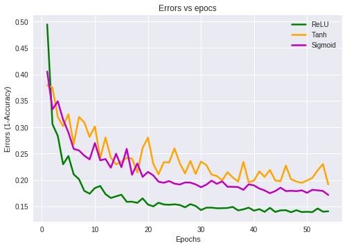

```python
errorPlot()
```

### Question-1 Graph of Prediction Loss vs Number of hidden layers

```python
def layersPlot():
    data=pd.read_csv("apparel-trainval.csv").values
    sigmoidError=[]
    reluError=[]
    tanhError=[]
    xlist=[i for i in range(0,6)]
    train,test=splitTrainTest(data,80)#train on 80% data
    oneHotLabelsTrain=getOneHotLabels(train,10)#10 is vector size
    oneHotLabelsTest=getOneHotLabels(test,10)
    trainInputs=train[:,1:]
    testInputs=test[:,1:]

    trainInputs=trainInputs/255
    testInputs=testInputs/255
    epochs=50
    batchSize=64

    for i in xlist:
        print(i)
        numberofLayers=2+i

        noofneurons=[784]+[16]*i+[10]
        activationFunctionsRelu=[None]+["relu"]*i+["softmax"]
        activationFunctionsSigmoid=[None]+["sigmoid"]*i+["softmax"]
        activationFunctionsTanh=[None]+["tanh"]*i+["softmax"]
#         print(noofneurons,activationFunctionsRelu,numberofLayers)
        nnSigmoid=NeuralNet(numberofLayers,noofneurons,activationFunctionsSigmoid)
        nnRelu=NeuralNet(numberofLayers,noofneurons,activationFunctionsRelu)
        nnTanh=NeuralNet(numberofLayers,noofneurons,activationFunctionsTanh)

        sigmoidError.append(nnSigmoid.trainNetwork(trainInputs,oneHotLabelsTrain,batchSize,epochs,0.1,False))
        reluError.append(nnRelu.trainNetwork(trainInputs,oneHotLabelsTrain,batchSize,epochs,0.1,False))
        tanhError.append(nnTanh.trainNetwork(trainInputs,oneHotLabelsTrain,batchSize,epochs,0.1,False))

#         sigmoidError.append(nnSigmoid.getAccuracy(testInputs, oneHotLabelsTest,True))
#         reluError.append(nnRelu.getAccuracy(testInputs, oneHotLabelsTest,True))
#         tanhError.append(nnTanh.getAccuracy(testInputs, oneHotLabelsTest,True))

    plt.title("Loss vs Number of layers")
    plt.xlabel("Hidden Layers (each with 16 neurons)")
    plt.ylabel("Loss (Cross Entropy)")
    plt.grid(True)
#     print(xlist,reluError,sigmoidError,tanhError)
    plt.plot(xlist,reluError ,color="green", linewidth=2.5,label="ReLU")
    plt.plot(xlist,tanhError,color="orange", linewidth=2.5,label="Tanh")
    plt.plot(xlist, sigmoidError,color="m", linewidth=2.5,label="Sigmoid")

    plt.legend(loc=0)
#     plt.show()
    plt.savefig("lossVsLayers.jpg")
```

```
0
0.35245321669402724
0.26519836501068667
0.37686615215471336
1
0.4038065909737556
0.2983709668793601
0.4497039449039033
2
0.4682090418671075
0.25252708746352037
0.3714640756401591
3
0.37885693907324236
0.23779637545342663
0.5065196824218023
4
0.46698762947488126
2.3025850929940455
0.45803606394588303
5
0.41330374477099663
2.3025850929940455
0.5450276878763922
```

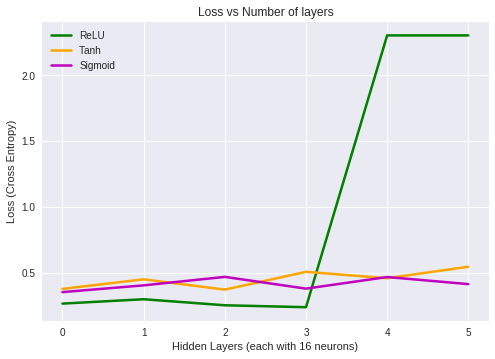

```python
layersPlot()
```

### Question-2 Report to use neural network for house price prediction

The given datasets for house price prediction tasks consists of numerical as well as categorical features.

The model for the neural network that we built only take numerical features into the considerations.

Numerical features need to to normalized with proper scale before use it to train neural network using the mean value and standard deviation of that feature.

There are so many features in the datasets which are categorical/discrete. Like

- Ms zoning
- Street
- LotConfig
- Neighbourhood etc.

So we need some kind of encoding and data preprocessing to convert these discrete values to approriate representation that can be used by our neural network.

#### Approach 1.

The categorical features contain no intrinsic ordering among their values. Simply mapping the data to a one-dimensional list of numbers would introduce an ordering to the categories and mislead classifiers. Hence, the categories should be treated as independent dimensions.

So we have to encode these features using **one-hot-encoding** where the length of the encoded vector is the number of categories and the bit in the vector (00001000...) is 1 for a particular category in the input signal.

Expanding categorical features to a number of new dimensions would sometimes make the dataset become too complex to handle. If it is the case, complexity of the dataset can be reduced by dimensionality reduction tools, like principle component analysis (PCA)

#### Approach 2.

The workhorse of Neural Network is the backpropagation algorithm, which uses dynamic programming to compute parameter gradients of the network. This assumes that immediate parameters/represenations are continuous.

What happens if we want to learn intermediate representations that are discrete?

We can use stochastic neural networks, where each layer compute the parameters of some (discrete) distribution, and its forward pass consists of taking a sample from that parametric distribution. However, the difficulty is that we can’t backpropagate through samples.

The problem of backpropagating through stochastic nodes can be circumvented Gumbel-Softmax Distribution.